# Poisson Mixtures

# Some Background Material

- [Review of Poisson Distribution](https://youtu.be/8zNYfvmwhcM?si=Up2CkS1uNlt2W6ie)
- [Review of Poisson Regression](https://youtu.be/yoRDj3JsEqE?si=fGyGTL50HLzCtCvH)
- [Overdispersion / Underdispersion](https://youtu.be/0_IUTi5Azyg?si=As3Sf6deAdv25S-b)

# Introduction

The Poisson distribution is a common choice for modeling count data, but real counts are typically *overdispersed*: their variance exceeds their mean. The Poisson distribution, in contrast, has a mean that equals its variance. A simple way to allow for over-dispersion is by using a mixture of Poisson distributions as follows:
$$Y_i|\gamma_i \sim \text{Poisson}(\gamma_i \mu), \quad \gamma_i \sim F_\theta$$
where $\gamma_i$ is an unobserved random variable. In this model, $Y_i$ is Poisson *conditional* on $\gamma_i$ but not unconditionally. By the law of iterated expectations:
$$\mathbb{E}[Y_i] = \mathbb{E}\left[ \mathbb{E}\left(Y_i|\gamma_i\right)\right] = \mathbb{E}[ \gamma_i \mu] = \mu \mathbb{E}[\gamma_i]$$
If we impose $\mathbb{E}[\gamma_i] = 1$ then $\mathbb{E}(Y_i)$ will equal $\mu$. By the the law of total variance:
$$\begin{align*}
\text{Var}[Y_i] &= \mathbb{E}\left[ \text{Var}\left(Y_i|\gamma_i\right)\right] + \text{Var}\left(\mathbb{E}\left(Y_i|\gamma_i\right)\right)\\
&= \mathbb{E}[\mu\gamma_i] + \text{Var}[\gamma_i\mu]\\
&= \mu \mathbb{E}[\gamma_i] + \mu^2 \text{Var}[\gamma_i]
\end{align*}$$
Thus, the variance of $Y_i$ is a function of both the mean and the variance of $\gamma_i$. If we impose $\mathbb{E}[\gamma_i]=1$ then $\text{Var}(Y_i) = \mu + \mu^2\, \text{Var}(\gamma_i)$. Since $\text{Var}(\gamma_i) \geq 0$, this model creates a count distribution with over-dispersion.

The same idea can be applied to a Poisson regression model, in which case $\mu$ is replaced by $\mu_i$ defined according to
$$\mu_i = \exp\left\{X_i'\beta \right\}$$
In the regression case, if $\mathbb{E}(\gamma_i)=1$, then the *conditional mean* given $X_i$ is unchanged from the plain-vanilla Poisson case but the *conditional variance* is inflated by the variance of $\gamma_i$. For the rest of this document we’ll consider a simple version of the Poisson regression model, namely
$$\mu_i = \exp\left\{\alpha + \beta X_i\right\} \iff \log \mu_i = \alpha + \beta X_i$$
It’s worth seeing what happens in this model if we do *not* constrain $\mathbb{E}(\gamma_i)=1$. Suppose that $\mathbb{E}(\gamma_i) = \bar{\gamma}$ and define $\tilde{\gamma}_i \equiv \gamma_i / \bar{\gamma}$ so that $\mathbb{E}(\tilde{\gamma}_i) = 1$. Then we can write
$$\begin{align*}
\gamma_i \mu_i &= \tilde{\gamma}_i \bar{\gamma} \exp\left\{\alpha + \beta X_i\right\} \\
&= \tilde{\gamma}_i \exp\left\{\alpha + \log \bar{\gamma} + \beta X_i\right\} \\
&= \tilde{\gamma}_i \exp\left\{\tilde{\alpha} + \beta X_i\right\}
\end{align*}$$
where we define $\tilde{\alpha} = \alpha + \log \bar{\gamma}$. Since conditioning on $\tilde{\gamma}_i$ is equivalent to conditioning on $\gamma_i$, we can see that the model with $\mathbb{E}(\gamma_i) = \bar{\gamma}$ is equivalent to the model with $\mathbb{E}(\gamma_i) = 1$ but with a different intercept term. The choice of scaling for $\gamma_i$ is therefore arbitrary and has no effect on the regression slope coefficients.

Another point to note is that the model in which $\mathbb{E}(\gamma_i)$ is unspecified is not identified, since we can always multiply $\gamma_i$ by a constant and subtract the natural log of that constant from $\alpha$ to obtain the same likelihood. So in practice we will always fix the mean of $\gamma_i$. Another way of thinking of this is to view the problem in terms of $\epsilon_i \equiv \log \gamma_i$, in which case we obtain
$$Y_i|X_i, \epsilon_i \sim \text{Poisson}(\exp\{\alpha + \beta X_i + \epsilon_i\}), \quad \epsilon_i \sim G_\varphi$$
Just as in an ordinary linear regression model, we cannot separately identify the intercept and the mean of the error term. As such we typically fix the mean of $\epsilon_i$ to be zero. This would be equivalent to fixing the mean of $\gamma_i$ to be one. But, again, we could fix the mean of $\epsilon_i$ to be any value and this would have no effect on the regression *slope* parameters.

A common choice of distribution for $\gamma_i$ is the gamma distribution, which ahs two parameters: a shape parameter $c > 0$ and a scale parameter $b > 0$
$$Z \sim \text{Gamma}(c, b) \iff f(z) = \frac{1}{\Gamma(c)b^c} z^{c-1} \exp\left\{-z/b\right\}$$

## Negative Binomial Example

### Frequentist Approach

```r
library(MASS)
library(BenfordTests)
library(tidyverse)
library(broom)
library(tolerance)

set.seed(1234)

# Simulate data from a negative binomial distribution
n <- 1000
x <- rnorm(n)
alpha <- 0.1
beta <- 0.5
phi <- 2

# Sample random populations
popn <- rbenf(n) |>
  exp() |>
  as.integer()



# This parameterization has a mean = mu and variance = (mu + mu^2 / size)
y <- rnbinom(n,
             mu = (popn / 1000) * exp(alpha + beta * (x - mean(x)) / sd(x)),
             size = phi)


# Fit a negative binomial regression model
reg1 <-  glm.nb(y ~ offset(log(popn / 1000)) + I(scale(x)))
summary(reg1)
```

```
Call:
glm.nb(formula = y ~ offset(log(popn/1000)) + I(scale(x)), init.theta = 2.393283593,
    link = log)

Coefficients:
            Estimate Std. Error z value Pr(>|z|)
(Intercept)  0.13800    0.05516   2.502   0.0124 *
I(scale(x))  0.37693    0.05816   6.481 9.09e-11 ***
---
Signif. codes:  0 '***' 0.001 '**' 0.01 '*' 0.05 '.' 0.1 ' ' 1

(Dispersion parameter for Negative Binomial(2.3933) family taken to be 1)

    Null deviance: 434.88  on 999  degrees of freedom
Residual deviance: 396.43  on 998  degrees of freedom
AIC: 1289.8

Number of Fisher Scoring iterations: 1

              Theta:  2.393
          Std. Err.:  0.383

 2 x log-likelihood:  -1283.781
```

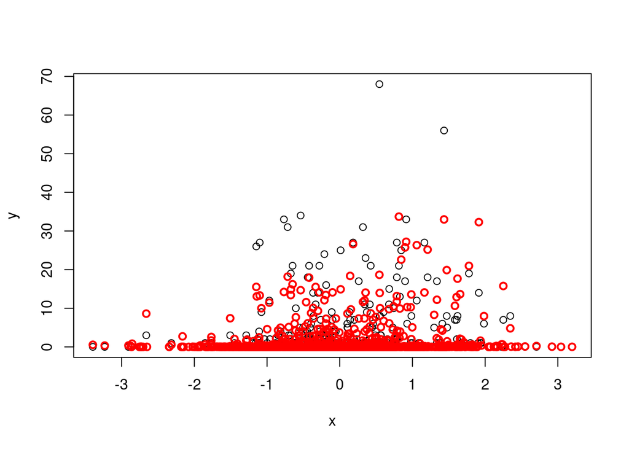

```r
plot(x, y)
# add plot of glm.nb fit
points(x, predict(reg1, type = "response"), col = "red", lwd = 2)
```

### Bayesian Approach with STAN

```r
library(cmdstanr)
nb_stan <- cmdstan_model('negative-binomial-regression.stan')
nb_stan$print()
```

```
data {
  int<lower=0> N;
  vector[N] popn; // real for taking logs below to avoid truncation!
  vector[N] x;
  array[N] int<lower=0> y;
}

transformed data {
  real x_bar = mean(x);
  real s_x = sd(x);
  vector[N] z = (x - x_bar) / s_x;
  vector[N] log_popn = log(popn / 1000); // log in thousands
}

parameters {
  real alpha;
  real beta;
  real<lower=0> phi;
}

model {
  y ~ neg_binomial_2_log(log_popn + alpha + beta * z, phi);
  // See if we can get away with flat priors
  //alpha ~ normal(3, 0.5);  // mean and sd
  //beta ~ normal(0, 0.2); // mean and sd
  //phi ~ ???
}
```

```r
dat <- list(
  N = n,
  y = y,
  x = x,
  popn = popn)

nb_fit <- nb_stan$sample(
  data = dat,
  seed = 1234,
  chains = 4,
  parallel_chains = 4,
  refresh = 500
)
```

```
Running MCMC with 4 parallel chains...

Chain 1 Iteration:    1 / 2000 [  0%]  (Warmup)
Chain 2 Iteration:    1 / 2000 [  0%]  (Warmup)
Chain 3 Iteration:    1 / 2000 [  0%]  (Warmup)
Chain 3 Iteration:  500 / 2000 [ 25%]  (Warmup)
Chain 4 Iteration:    1 / 2000 [  0%]  (Warmup)
Chain 1 Iteration:  500 / 2000 [ 25%]  (Warmup)
Chain 1 Iteration: 1000 / 2000 [ 50%]  (Warmup)
Chain 1 Iteration: 1001 / 2000 [ 50%]  (Sampling)
Chain 2 Iteration:  500 / 2000 [ 25%]  (Warmup)
Chain 4 Iteration:  500 / 2000 [ 25%]  (Warmup)
Chain 2 Iteration: 1000 / 2000 [ 50%]  (Warmup)
Chain 2 Iteration: 1001 / 2000 [ 50%]  (Sampling)
Chain 3 Iteration: 1000 / 2000 [ 50%]  (Warmup)
Chain 3 Iteration: 1001 / 2000 [ 50%]  (Sampling)
Chain 4 Iteration: 1000 / 2000 [ 50%]  (Warmup)
Chain 4 Iteration: 1001 / 2000 [ 50%]  (Sampling)
Chain 1 Iteration: 1500 / 2000 [ 75%]  (Sampling)
Chain 2 Iteration: 1500 / 2000 [ 75%]  (Sampling)
Chain 3 Iteration: 1500 / 2000 [ 75%]  (Sampling)
Chain 4 Iteration: 1500 / 2000 [ 75%]  (Sampling)
Chain 1 Iteration: 2000 / 2000 [100%]  (Sampling)
Chain 1 finished in 0.6 seconds.
Chain 2 Iteration: 2000 / 2000 [100%]  (Sampling)
Chain 3 Iteration: 2000 / 2000 [100%]  (Sampling)
Chain 4 Iteration: 2000 / 2000 [100%]  (Sampling)
Chain 2 finished in 0.6 seconds.
Chain 3 finished in 0.6 seconds.
Chain 4 finished in 0.6 seconds.

All 4 chains finished successfully.
Mean chain execution time: 0.6 seconds.
Total execution time: 0.8 seconds.
```

```r
nb_fit$summary() |>
  knitr::kable(digits = 3)
```

| variable | mean | median | sd | mad | q5 | q95 | rhat | ess_bulk | ess_tail |
| --- | --- | --- | --- | --- | --- | --- | --- | --- | --- |
| lp__ | -642.469 | -642.167 | 1.178 | 0.954 | -644.853 | -641.180 | 1.000 | 2228.141 | 2713.991 |
| alpha | 0.140 | 0.140 | 0.054 | 0.055 | 0.050 | 0.229 | 1.001 | 3562.632 | 3151.105 |
| beta | 0.377 | 0.376 | 0.061 | 0.060 | 0.279 | 0.479 | 1.001 | 3469.069 | 2943.840 |
| phi | 2.461 | 2.429 | 0.392 | 0.380 | 1.880 | 3.174 | 1.000 | 3408.540 | 2529.782 |